# Pre-course assignments to use Python and R

Authors

Maximilian Nuber

Junyan Lu

# 1 A Multi-Lingual Approach to Multi-Omics

In the rapidly evolving landscape of single-cell genomics, the “best” tool is often defined by the task at hand rather than a single programming language. While your previous lectures have established a strong foundation in R—utilizing the robust Bioconductor ecosystem for statistical analysis and tools like MOFA—the state of the art in multi-omics integration frequently leans on Python-based deep learning frameworks like scVI. To reflect this reality, this course adopts a pragmatic, dual-language approach. The following chapters are designed to bridge the gap between these environments, allowing you to build upon your existing R expertise while gaining the fluency needed to navigate Python when the biology demands it. Whether you choose to work primarily in R or Python for your daily tasks, our goal is to empower you to treat these languages as complementary tools, ensuring you can always reach for the most effective method for your data.

# 2 A note on `conda` vs. Docker + `uv`

Conda is a mini operating system in a folder: it manages not just Python packages but also system-level dependencies — compiled C libraries, OpenSSL, HDF5, even R — all isolated from your host machine. This makes it powerful but heavy, and environment solves can be slow and brittle as dependency trees grow. The Docker + uv approach divides these responsibilities more cleanly between two purpose-built tools. Docker provides the system layer: the base image (e.g., a Bioconductor image) ships with R, Bioconductor packages, and all compiled system dependencies pre-installed and version-locked at the OS level. Within that container, uv handles everything Python: it resolves and installs packages at high speed, pins the full dependency graph in a uv.lock file for exact reproducibility, and manages virtual environments without ever touching system paths. The result is a cleaner separation of concerns — Docker owns the system, uv owns Python — and both layers are independently reproducible and auditable.

# 3 Setting up Python with `conda`

For processing and analyzing single-cell data, we will be using Python as part of this lecture. For reproducible Python workflows we use `conda`, which loads and installs a mini-system and Python inside. This includes software, which would otherwise be installed on your computer (e.g. `hdf5`)

`conda` should not be confused with “Anaconda”, the company. `conda` is an open-source software, which installs pre-compiled binaries (what compilation produces), Anaconda is a company hosting thees binaries on servers.

Because Anaconda is commercial, alternative channels have emerged, such as `conda-forge` and `bioconda`, which we will be using.

Please note, `bioconda` hosts Python and R-packages we require, but is not available for Windows. Therefore, seriously consider abandoning Windows entirely, otherwise dual-boot will do (https://www.youtube.com/watch?v=qq-7X8zLP7g). Windows-only Users can´t be helped.

The exact software we want to download is `miniforge3`. This is basically the same as `conda`, or rather `miniconda` (fewer pre-installed packages), but natively includes both the `conda` and `mamba` commands. If you ever see something done using the `conda` command, you can replace that with `mamba` and it will be faster.

For Unix-based systems, the most robust method is using the shell script installer. These commands automatically detect your architecture (Intel vs. Apple Silicon/ARM). In a terminal, run:

```python
# 1. Download the latest installer script
curl -L -O "https://github.com/conda-forge/miniforge/releases/latest/download/Miniforge3-$(uname)-$(uname -m).sh"

# 2. Run the installer (Interactive)
bash Miniforge3-$(uname)-$(uname -m).sh

# OR: Run a "Silent" install (Batch mode) to a specific directory
# bash Miniforge3-$(uname)-$(uname -m).sh -b -p ~/miniforge3
```

Initialize the Shell

After installation, you must initialize your shell so the conda command is recognized:

```python
~/miniforge3/bin/conda init  # Use the path where you installed it
source ~/.bashrc             # For Linux (or ~/.zshrc for macOS)
```

For Windows users, these are the commands to install. However, I cannot verify this due to lack of Windows computers I can test on. Remember, that `bioconda` packages cannot be used on Windows.

```python
# 1. Download the installer via PowerShell
Invoke-WebRequest -Uri "https://github.com/conda-forge/miniforge/releases/latest/download/Miniforge3-Windows-x86_64.exe" -OutFile "Miniforge3.exe"

# 2. Run silent installation
Start-Process -FilePath ".\Miniforge3.exe" -ArgumentList "/S", "/InstallationType=JustMe", "/D=$HOME\miniforge3" -Wait

# Initialize
& "$HOME\miniforge3\condabin\conda.bat" init
```

Now you can install `conda`-environments with Python:

```python
conda create -n test_env python=3.12

# or we do
mamba create -n test_env python=3.12
```

This command creates the environment `test_env`, with python 3.12.x installed inside. There is always an environment active. Without expilitely activating and env, “base” is active, your own computer/system. We want to activate the environment, and then start installing into the environment:

```python
conda activate test_env
conda install conda-forge::scanpy conda-forge::pandas conda-forge::numpy conda-forge::igraph
mamba install decoupler-py

pip install biocutils
pip install singlecellexperiment
pip install scranpy
```

`conda` and `mamba` install pre-compiled from one of the channels, `pip` builds the packages from the ground up (like running Python-files when installing).

Note: earlier I mentioned installing from Anaconda, conda-forge, or bioconda. With miniforge, we automatically install from conda-forge, so you don’t need to worry.

For reproducibitly, we want to write and use `.yaml` files. With the command below, we install an environment and install every package, including versions from a file we specify:

```python
conda env create --name env_from_yaml -f /path/to/file.yaml
```

Importantly, how do we conveniently write code? I suggest JupyterLab. Jupyter Notebooks are a long-standing standard for itneractive use of Python. They are similar to RMarkdown, but have their own gimmicks. We can use them for running Python, or R if we wish.

JupyterLab is the package we install to get access to Jupyter Notebooks:

```python
conda install conda-forge::jupyterlab conda-forge::ipywidgets
```

When installed we first need to start Jupyter. But instead of an own window, it uses the browser to display everything we need:

```python
jupyter lab
```

When we are done with the session:

```python
conda deactivate
```

And when we want to remove the environment:

```python
conda remove --name test_env --all
```

Source: Setting up Python with `conda`

# 4 Setting up Python with `uv` inside Docker

For this lecture, we use a Docker container as the base system and then manage Python with `uv` inside that container. This avoids most host-specific dependency issues and gives us reproducible environments for notebooks and scripts.

You already have a conda-based setup notebook. This notebook focuses on the Docker + `uv` workflow, which is often faster for package resolution and cleaner for project-local environments.

## 4.1 Why this stack?

- Docker gives us a stable Linux base image with R/Bioconductor and system libraries.
- `uv` gives us fast Python dependency management and project-local virtual environments.
- We can mix R-native workflows, `reticulate`, and Python in one reproducible setup.

## 4.2 1. Full Dockerfile (copy/paste)

Below is one complete Dockerfile that combines the Bioconductor Image with extra system dependencies (including fonts) used for `rpy2` + `uv` workflows.

Depending on different installation paths, we may or may not manually export some settings inside the docker container:

```
export R_HOME="$(R RHOME)"
export CC=/usr/bin/gcc
export CXX=/usr/bin/g++
export LDFLAGS="-L/usr/local/lib/R/lib -L/usr/lib/x86_64-linux-gnu"
export CPPFLAGS="-I/usr/include -I/usr/include/tirpc"
export LD_LIBRARY_PATH="/usr/local/lib/R/lib:/usr/lib/x86_64-linux-gnu:${LD_LIBRARY_PATH}"
```

```python
# Base image: Bioconductor (R 4.6 + RStudio)
FROM bioconductor/bioconductor_docker:RELEASE_3_23

ENV LANG=C.UTF-8
ENV LC_ALL=C.UTF-8

# Environment variables
ENV CONDA_DIR=/opt/conda
ENV PATH=${CONDA_DIR}/bin:/root/.cargo/bin:$PATH
ENV MAKE="make"
ENV MAKEFLAGS="-j4"

# System dependencies (combined original + extra rpy2/plotting deps)
RUN apt-get update && apt-get install -y --no-install-recommends \
    curl \
    git \
    build-essential \
    gcc \
    g++ \
    gfortran \
    make \
    cmake \
    pkg-config \
    libpcre2-dev \
    libdeflate-dev \
    liblzma-dev \
    zlib1g-dev \
    libbz2-dev \
    libzstd-dev \
    libicu-dev \
    libtirpc-dev \
    libxml2-dev \
    libssl-dev \
    libcurl4-openssl-dev \
    libv8-dev \
    libhdf5-dev \
    libffi-dev \
    libreadline-dev \
    libsqlite3-dev \
    tk-dev \
    libpng-dev \
    libjpeg-dev \
    libfreetype6-dev \
    fontconfig \
    fonts-dejavu-core \
    fonts-dejavu-extra \
    fonts-liberation \
    fonts-freefont-ttf \
    && apt-get clean && rm -rf /var/lib/apt/lists/*

# Refresh font cache
RUN fc-cache -fv

# Switch user so Rust installs into /home/rstudio/.cargo
USER rstudio

# Install Rust
RUN curl --proto '=https' --tlsv1.2 -sSf https://sh.rustup.rs | sh -s -- -y

# Make cargo available in shell
ENV PATH="/home/rstudio/.cargo/bin:${PATH}"

# Make cargo available to R sessions (.Renviron is read by R)
RUN echo 'PATH=${PATH}:/home/rstudio/.cargo/bin' >> /home/rstudio/.Renviron

# Switch back to root
USER root

# Install Miniforge3
RUN curl -L https://github.com/conda-forge/miniforge/releases/latest/download/Miniforge3-Linux-x86_64.sh -o miniforge.sh \
    && bash miniforge.sh -b -p ${CONDA_DIR} \
    && rm miniforge.sh \
    && conda config --set auto_update_conda False

# Install uv from official image
COPY --from=ghcr.io/astral-sh/uv:latest /uv /uvx /usr/bin/

# Configure R + reticulate to use uv-managed environments
ENV RETICULATE_PYTHON_PREFERENCE=system
ENV RETICULATE_USE_MANAGED_VENV=yes

# Pre-install core R packages
RUN R -e "BiocManager::install(c('scran', 'scater', 'muscat', 'Rhdf5lib', 'edgeR', 'limma', 'glmGamPoi', 'DESeq2'), ask=FALSE)"
RUN R -e "BiocManager::install(c('basilisk', 'SingleCellExperiment', 'SparseArray', 'scrapper', 'sketchR'), ask=FALSE)"

RUN R -e "BiocManager::install(c('alabaster.base', 'alabaster.sce'), ask=FALSE)"

RUN R -e "BiocManager::install(c('lemur', 'MOFA2'), ask=FALSE)"
RUN R -e "BiocManager::install(c('decoupleR', 'clusterProfiler'), ask=FALSE)"
RUN R -e "BiocManager::install(c('ggplot2', 'scattermore', 'patchwork', 'cowplot', 'ComplexHeatmap', 'pheatmap', 'ggrastr'), ask=FALSE)"
RUN R -e "BiocManager::install(c('ggsci'), ask=FALSE)"
RUN R -e "BiocManager::install(c('reticulate', 'anndataR'), ask=FALSE)"

RUN R -e "BiocManager::install(c('tidyverse'), ask=FALSE)"


# Required installs to use R in Jupyter notebooks:

# Update and install the jupyter-client binary
RUN apt-get update
RUN apt-get install -y jupyter-client


RUN R -e "install.packages('IRkernel')"
RUN R -e "IRkernel::installspec(user = FALSE)"


RUN R -e "BiocManager::install(c('airway', 'TENxPBMCData'))"

WORKDIR /home/rstudio/project
```

## 4.3 2. Build the Docker image

Assuming your Dockerfile is in the current directory, build the image with a lecture tag:

```python
docker build -t sc-lecture:bioc-r45-uv .
```

## 4.4 3. Start a container

Mount your project directory and expose useful ports (RStudio and Jupyter):

```python
docker run --rm -it \
  --name sc-lecture \
  -p 8787:8787 \
  -p 8888:8888 \
  -v "$(pwd)":/home/rstudio/project \
  sc-lecture:bioc-r45-uv
```

If you start it detached, you can enter it later using `docker exec`.

```python
docker run -d --rm \
  --name sc-lecture \
  -p 8787:8787 -p 8888:8888 \
  -v "$(pwd)":/home/rstudio/project \
  sc-lecture:bioc-r45-uv

docker exec -it sc-lecture bash
```

## 4.5 4. Verify tools in container

Inside the container, check that `uv`, Python, and R are available:

```python
uv --version
python --version
R --version
```

## 4.6 5. Install extra OS packages (if needed)

Some Python or R packages require system libraries at compile/runtime. If your base image does not already include what you need:

```python
apt-get update
apt-get install -y --no-install-recommends \
  build-essential gcc g++ gfortran make cmake pkg-config \
  libpcre2-dev libdeflate-dev liblzma-dev zlib1g-dev libbz2-dev libzstd-dev \
  libicu-dev libtirpc-dev libxml2-dev libssl-dev libcurl4-openssl-dev \
  libpng-dev libjpeg-dev libfreetype6-dev libhdf5-dev

apt-get install -y --no-install-recommends \
  fontconfig fonts-dejavu-core fonts-dejavu-extra fonts-liberation fonts-freefont-ttf

fc-cache -fv
```

In your current Dockerfile, most critical dependencies are already installed, so this step is often unnecessary during day-to-day work.

## 4.7 6. `uv` project strategy for data analysis

`uv` was designed for software projects, but in analysis workflows we often want different dependency sets per stage. For example, preprocessing, integration, and VDJ analysis can each have their own environment.

```python
project/
  01_preprocessing/
    pyproject.toml
    uv.lock
    .venv/
    preprocess.ipynb
    run_preprocess.py

  02_totalvi/
    pyproject.toml
    uv.lock
    .venv/
    totalvi.ipynb
    run_totalvi.py

  03_vdj/
    pyproject.toml
    uv.lock
    .venv/
    clonotypes.ipynb
```

This pattern improves reproducibility and avoids one oversized environment for everything.

## 4.8 6. Create one stage-specific `uv` project

Example for `01_preprocessing`:

```python
cd /home/rstudio/project/project
mkdir -p 01_preprocessing
cd 01_preprocessing

uv init --python 3.12
uv add scanpy anndata pandas numpy matplotlib jupyterlab ipykernel
uv sync
```

If you already wrote a `pyproject.toml`, install exactly what is specified there with:

```python
uv sync
```

## 4.9 7. Register a Jupyter kernel from this `uv` environment

This lets notebooks in JupyterLab use the environment of this stage:

```python
uv run python -m ipykernel install \
  --user \
  --name sc-preprocess-uv \
  --display-name "Python (sc preprocess uv)"
```

Start JupyterLab inside that stage folder:

```python
uv run jupyter lab --ip=0.0.0.0 --port=8888 --no-browser
```

## 4.10 8. Repeat per analysis stage

Create one `uv` project per stage and install only what that stage needs.

```python
cd /home/rstudio/project/project/02_totalvi
uv init --python 3.12
uv add scvi-tools anndata pandas numpy jupyterlab ipykernel
uv sync

cd /home/rstudio/project/project/03_vdj
uv init --python 3.12
uv add scirpy awkward pandas numpy jupyterlab ipykernel
uv sync
```

## 4.11 9. Run scripts with project environments

Because each stage has its own `.venv`, running scripts stays isolated and reproducible:

```python
cd /home/rstudio/project/project/01_preprocessing
uv run python run_preprocess.py

cd /home/rstudio/project/project/02_totalvi
uv run python run_totalvi.py
```

## 4.12 10. One-off script dependencies with uv

For quick utility scripts, `uv` can create a temporary environment from inline dependency metadata. This is convenient for scripts that are not part of a full project.

```python
# Example script header (PEP 723 style):
# /// script
# dependencies = [
#   "pandas",
#   "anndata"
# ]
# ///

uv run quick_check.py
```

## 4.13 11. Practical notes

- Commit `pyproject.toml` and `uv.lock` for each stage.
- Do not commit `.venv/`.
- Keep environment scopes narrow; add packages only where needed.
- If plotting looks wrong in headless/container environments, ensure fonts are installed.
- If a package build fails, check missing OS libraries first (not only Python versions).

## 4.14 12. Troubleshooting examples

When package combinations conflict or binary wheels are unavailable, these commands are commonly useful:

```python
uv pip install --force-reinstall --upgrade matplotlib
uv pip install --pre --upgrade "plotnine>=0.16.0a0"
```

This keeps the lecture workflow modular: Docker controls the system foundation, and `uv` controls Python dependencies per analysis stage.

Source: Setting up Python with `uv` inside Docker

# 5 Using R inside Python notebooks

While Python has solidified its position as the powerhouse for high-performance single-cell preprocessing and deep learning integration (thanks to the Scanpy and scvi-tools ecosystems), the R environment remains an indispensable titan of statistical bioinformatics.

The primary reason we bridge these two worlds is Bioconductor: a massive, peer-reviewed repository of over 2,000 packages that has served as the gold standard for genomic analysis for decades. Many “gold-standard” statistical methods—such as the rigorous differential expression testing of DESeq2, complex multi-modal integration in Seurat, or specialized trajectory inference tools—are natively built for R. Furthermore, R’s visualization capabilities via ggplot2 and its derivatives often provide a level of “publication-ready” aesthetic control that is difficult to replicate elsewhere (even though `plotnine` is getting close). In reproducible bioinformatics, we want to run and render seamless reports utilizing packages across languages, based on scientific merit. By mastering interoperability, you are building a hybrid pipeline that leverages Python’s computational speed for data crunching and R’s statistical depth for biological interpretation.

## 5.1 On `rpy2` and language interoperability

In this and the upcoming notebooks, we demonstrate Python workflows and Python-based interoperability due to the wide availability of single-cell multi-omics integration methods in Python. The natural choice for interoperability is therefore `rpy2`, to call R. However, `rpy2` is verbose, and users must account for many technical details. Therefore, we are using a package from GitHub `bioc2ri`, which is a convenience layer around `rpy2`, with easier access to functionalites, and pre-amde conversions to R-objects.

As R has been introduced and utilized in the previous lectures, we are focusing on the Python-side interoperability. However, for all tasks, experienced users may go R-first, and use `reticulate` for calling Python from R, if desired.

This and all upcoming notebooks can of course be used either with conda-env or inside docker. We found, that language interoperability with `rpy2` is much easier with docker + uv-installed Python environment.

As an example for a conda-env, you may find the respective configuration `.yaml`-file in `00_prep_python_uv/conda_envs/lecture__r_interop.yaml`. Otherwise, the `uv`-venv is installed inside `00_prep_python_uv/`.

```python
import os
import sys
%load_ext autoreload
%autoreload 2

### This is only necessary when using conda in docker containers:


# Get the directory of the current Conda environment
# conda_prefix = sys.prefix

# # Force R_HOME to point to the R inside this Conda environment'
# os.environ['R_HOME'] = f"{conda_prefix}/lib/R"

# # Optional: Ensure the Conda R bin is at the front of the PATH
# os.environ['PATH'] = f"{conda_prefix}/bin:" + os.environ.get('PATH', '')
###



### Load the convenience library
# Now you can safely import rpy2 or your package
from bioc2ri.lazy_r_env import get_r_environment
r = get_r_environment()

from bioc2ri import pandas_plugin
import pandas as pd
```

## 5.2 Installing packages

When using a `conda`-based R for interoperability, we would install R packages with conda, as you may see in the configuration yaml-file for this notebook (see above). If using `uv`, with or without docker, we are just using R installed on the computer. You could start RStudio and install the packages there, or start the terminal, and install whatever you need.

```
R

install.packages('tidyverse')
BiocManager::install('scrapper')
```

## 5.3 Differential Expression Example

This section of the notebook illustrates the “Hybrid Pipeline” in action. We will perform the heavy lifting of loading and subsetting in Python, then hand the data over to the Bioconductor ecosystem to run a statistically rigorous Differential Expression (DE) analysis using `edgeR` and `limma`.

**Data Preparation**

Fetching the “Airway” Dataset via R: We will use R to load the data, then use your core_eng to bring it into a Python AnnData object. This is a great “meta” demonstration: using R as a data provider for Python.

This section demonstrates the core of our interoperability workflow: fetching a “Gold Standard” dataset from the R Bioconductor ecosystem and mapping it into a Python AnnData object.

In this example, we use the Airway dataset, which consists of human airway smooth muscle cells treated with dexamethasone. Since this is a classic bulk RNA-seq dataset natively packaged for R, we use our custom engine to “translate” the R object into a format compatible with Python’s single-cell ecosystem.

**Key Concepts in this Cell**:

1. Object Mapping: We are converting an R SingleCellExperiment (SCE) into a Python AnnData object. Our custom engine, core_eng, handles the complex task of ensuring that R’s “assays” become Python “layers” and R’s “colData” becomes Python “obs”.
2. The Matrix Transpose: One of the most critical steps in bioinformatics interoperability is handling memory layout.
   - R (Bioconductor) stores data as Genes (Rows) × Samples (Columns).
   - Python (Scanpy/AnnData) stores data as Samples (Rows) × Genes (Columns). Our engine automatically transposes the matrices during the r2py call to ensure the biology remains aligned.
3. Layer-Centric Design: By default, Python’s .X slot is often used for the “currently active” data (like normalized or log-transformed values). To maintain transparency, we move the raw counts into a named layer (adata.layers[“counts”]) and leave .X empty. This forces downstream analysis steps to be explicit about which data layer they are using.

```python
from rpy2.robjects import r
from rpy2.robjects.packages import importr
import anndata as ad
from bioc2ri.anndata_sce_plugin import anndata2sce_plugin
from bioc2ri.pandas_plugin import pandas_plugin

# Initialize the conversion engine
core_eng = anndata2sce_plugin()
pd_eng = pandas_plugin()

# 1. Load the data in R
# airway contains transcriptomic data from human airway smooth muscle cells
airway_pkg = importr("airway")
r("data(airway)")

# Coerce the RangedSummarizedExperiment to a SingleCellExperiment for our engine
r_airway = r("as(airway, 'SingleCellExperiment')")

# 2. Convert to AnnData using the r2py (R-to-Python) method
# This handles the transposition and metadata mapping automatically
adata = core_eng.r2py(r_airway)

# 3. Clean up: Move the primary assay from .X to a named 'counts' layer
if "counts" not in adata.layers and "X" in adata.layers:
    adata.layers["counts"] = adata.layers.pop("X")

# Clear .X to demonstrate a layer-centric workflow
adata.X = None

print(f"Loaded Airway dataset: {adata.n_obs} samples, {adata.n_vars} genes.")
print(f"Metadata columns: {adata.obs.columns.tolist()}")


# Filter genes with zero counts across all samples
# Note: Since data is in .layers['counts'], we check there
gene_mask = adata.layers['counts'].sum(axis=0) > 0
adata = adata[:, gene_mask].copy()

# Ensure 'dex' (the treatment) is a category for R factors
adata.obs['dex'] = pd.Categorical(adata.obs['dex'])

print(f"Post-filtering: {adata.n_vars} genes remaining.")
```

```
(8, 9)
(63677, 10)
Loaded Airway dataset: 8 samples, 63677 genes.
Metadata columns: ['SampleName', 'cell', 'dex', 'albut', 'Run', 'avgLength', 'Experiment', 'Sample', 'BioSample']
Post-filtering: 33469 genes remaining.
```

Moving to Interactive R: IPython Magics

While the engine handles the data transfer, we can also change how we write code.

By loading the rpy2.ipython extension, we can turn any notebook cell into an R console using the %%R command. This is perfect for when you want to use R for a specific task (like plotting a quick ggplot2) without leaving your Python environment.

```python
# Load IPython magic:
%load_ext rpy2.ipython
```

Now that we have our data cleaned and organized in Python, we need to “hand it back” to the R environment to perform the statistical testing.

This step involves two distinct actions: Translation and Assignment.

1. Translation: Python → R (py2r)The first line, r_sce = core_eng.py2r(adata), is where our engine performs its most critical task. It takes the Python AnnData object and rebuilds it as a native R SingleCellExperiment.

During this process, the engine automatically: - Transposes the data: It flips the $Samples \times Genes$ matrix back into the $Genes \times Samples$ format that Bioconductor expects. - Maps Metadata: It ensures that your adata.obs (sample information like treatment groups) is converted into an R DataFrame that R’s statistical models can read.

In programming terms, we are taking the R object we just created in Python memory and assigning it to a global variable named “sce” inside the R interpreter. This is like “pinning” a document to a shared bulletin board; once it’s assigned, any subsequent R code—whether run via a magic cell (%%R) or a script—will be able to see and use the object sce.

```python
# 1. Translate the Python AnnData object into a native R SingleCellExperiment
# This handles the memory layout flip (transposition) automatically.
r_sce = core_eng.py2r(adata)

# 2. Assign the object to a variable named "sce" in the R global environment.
# Now, any R code we run will recognize "sce" as our dataset.
r.assign("sce", r_sce)
```

```
<rpy2.robjects.methods.RS4 object at 0x7bce3c45fcd0> [25]
R classes: ('SingleCellExperiment',)
```

**Statistical Modeling in R (limma-voom)**

Once the data is “pushed” to the R environment, we use the %%R cell magic to run a specialized Bioconductor workflow.

**The Interoperability Logic:**

- Direct Access: R recognizes the sce object we created in Python, allowing us to use the dex metadata column directly in our statistical design.
- Specialized Tools: We use edgeR for data containerization and limma-voom for the analysis.
- The Voom Advantage: It transforms raw counts into weighted log-CPM values, making them compatible with fast linear modeling while accounting for the mean-variance relationship typical of RNA-seq.

**Workflow Summary:**

1. Filter & Normalize: Remove low-count genes and normalize library sizes.
2. Model Design: Define the experimental comparison (Treated vs. Control).
3. Voom Transformation: Convert counts to weighted linear values.
4. Linear Fit: Use eBayes to share statistical power across all genes, stabilizing the results even with small sample sizes.

By running this in an R magic cell, we leverage R’s industry-standard biostatistics without ever leaving our Python-based notebook.

```python
%%R
library(edgeR)
library(limma)

# 1. Prepare the DGEList from our SCE
# We pull the 'counts' assay we moved into R
dge <- DGEList(counts = assay(sce, "counts"))

# 2. Filter and Normalize
# filterByExpr automatically removes genes with too few counts to be statistically useful
keep <- filterByExpr(dge, group = sce$dex)
dge <- dge[keep, , keep.lib.sizes=FALSE]
dge <- calcNormFactors(dge)

# 3. Define the Design Matrix
# We use the 'dex' column directly from the SingleCellExperiment metadata
design <- model.matrix(~ dex, data = colData(sce))

# 4. The voom transformation
# This converts counts to log2-counts per million (logCPM)
# and calculates the mean-variance weights.
v <- voom(dge, design, plot = FALSE)

# 5. Linear Modeling with limma
# fit: fits a linear model for each gene
# eBayes: performs empirical Bayes shrinkage on the variances
fit <- lmFit(v, design)
fit <- eBayes(fit)

# 6. Extract Results
# coef=2 corresponds to the dex treatment effect
res_df <- topTable(fit, coef = 2, n = Inf, sort.by = "P")
```

```python
# 3. Bring results back to Python
# Our pandas_plugin handles the conversion of the results table
de_results = pd_eng.r2py(r["res_df"])
display(de_results.head())
```

|  | logFC | AveExpr | t | P.Value | adj.P.Val | B |
| --- | --- | --- | --- | --- | --- | --- |
| ENSG00000152583 | -4.574855 | 4.167526 | -18.527604 | 2.194744e-08 | 0.000204 | 9.297282 |
| ENSG00000134686 | -1.381139 | 6.839533 | -16.899763 | 4.853259e-08 | 0.000204 | 9.209304 |
| ENSG00000179094 | -3.185870 | 4.421045 | -16.593010 | 5.681830e-08 | 0.000204 | 8.877958 |
| ENSG00000125148 | -2.198075 | 7.024695 | -16.376151 | 6.362189e-08 | 0.000204 | 8.942174 |
| ENSG00000148175 | -1.440288 | 8.856653 | -16.359733 | 6.417269e-08 | 0.000204 | 8.799960 |

To wrap up the workflow, we compare the visualization capabilities of both ecosystems. One of the most powerful aspects of this interoperability is that you can now use the Grammar of Graphics in both languages.

**The Grammar of Graphics: plotnine vs. ggplot2** Historically, Python users had to switch between matplotlib and seaborn, which use different logic than R’s ggplot2. However, plotnine has matured significantly and is now a high-quality, feature-complete implementation of the Grammar of Graphics for Python.

This means you can use nearly identical syntax to generate publication-quality plots in either environment, making the transition between Python and R practically seamless for visualization.

1. Visualization in Python (plotnine)

We’ll start by creating a Volcano Plot using plotnine. Notice how the syntax mirrors R almost perfectly.

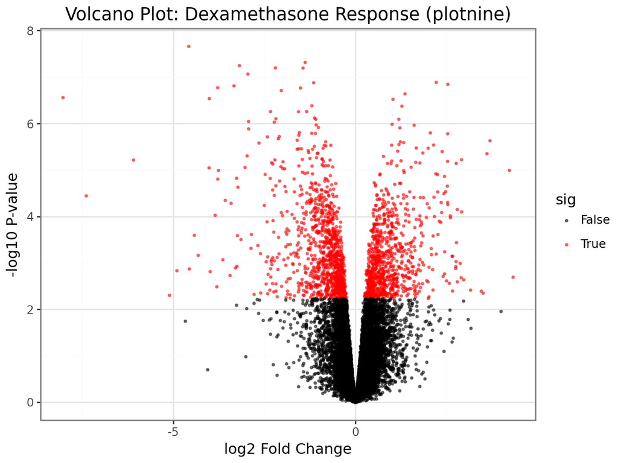

```python
from plotnine import *
import numpy as np

# Adding a significance column for coloring
de_results['sig'] = de_results['adj.P.Val'] < 0.05
de_results["neg_log10"] = np.log10(de_results["P.Value"]) * -1

p = (
    ggplot(de_results, aes(x='logFC', y='neg_log10', color='sig'))
    + geom_point(alpha=0.5, size=0.5)
    + scale_color_manual(values=['black', 'red'])
    + theme_bw()
    + labs(
        title="Volcano Plot: Dexamethasone Response (plotnine)",
        x="log2 Fold Change",
        y="-log10 P-value"
    )
)
p
```

2. Visualization in R (ggplot2)

To demonstrate the parity, we run the same visualization logic inside our R magic cell using the original res_df.

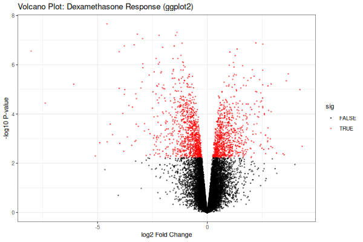

```python
%%R -w 600 -h 400
library(ggplot2)

# Ensure significance is a factor for plotting
res_df$sig <- res_df$adj.P.Val < 0.05

ggplot(res_df, aes(x=logFC, y=-log10(P.Value), color=sig)) +
  geom_point(alpha=0.5, size=0.5) +
  scale_color_manual(values=c("black", "red")) +
  theme_bw() +
  labs(
    title="Volcano Plot: Dexamethasone Response (ggplot2)",
    x="log2 Fold Change",
    y="-log10 P-value"
  )
```

Source: Using R inside Python notebooks